# 作业2编程题

加兴华

2024-03-27

## 1.

模拟

```r
simulation <- function(sample_size, beta) {
  X <- cbind(1, matrix(rnorm(sample_size * (length(beta) - 1)), nrow = sample_size))
  Y <- rbinom(sample_size, 1, plogis(X %*% beta))
  return(list(X=X,Y=Y))
}

# e.g.
# result <- simulation(200,c(0.5,1.2,-1))
```

N-R算法

```r
NR <- function(X, Y, max_iter = 1000, err = 1e-5) {
  n <- nrow(X)
  p <- ncol(X)
  beta <- rep(0, p)
  converged <- FALSE
  iter <- 1

  while (!converged && iter <= max_iter) {
    p <- exp(X %*% beta) / (1 + exp(X %*% beta))
    W <- diag(c(p * (1 - p)))
    gradient <- t(X) %*% (Y - p)
    hessian <- -t(X) %*% W %*% X
    update <- solve(hessian, gradient)
    beta_new <- beta - update

    if (max(abs(beta_new - beta)) < err) {
      beta <- beta_new
      break
    }

    beta <- beta_new
    iter <- iter + 1
  }

  return(beta)
}

# e.g.
# result <- simulation(200,c(0.5,1.2,-1))
# est <- NR(result$X,result$Y)
```

重复实验

```r
N = c(200,500,800,1000)
R = 200
beta = c(0.5,1.2,-1)
experiments <- list()
for(sample_size in N) {
  ests <- matrix(NA, nrow = R, ncol = length(beta))
  for (r in 1:R) {
    simulated_data <- simulation(sample_size,beta)
    est <- NR(simulated_data$X,simulated_data$Y)
    ests[r, ] <- est
  }
  experiments[[as.character(sample_size)]]=ests
}
```

绘制箱线图

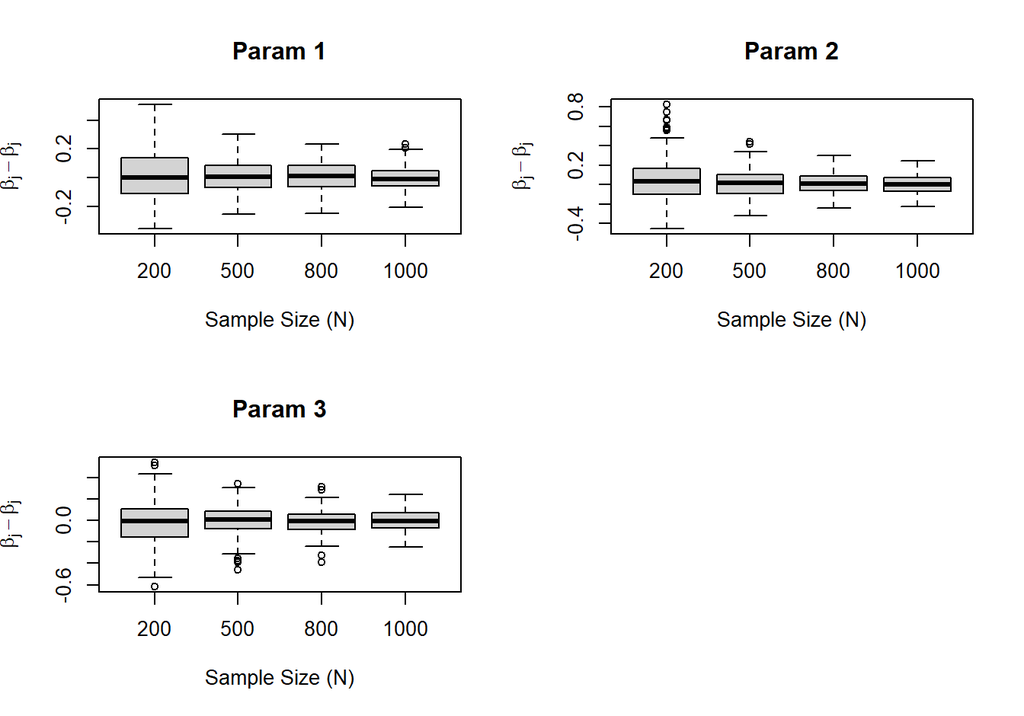

```r
par(mfrow = c(2, 2))

for (j in 1:length(beta)) {
  diff <- lapply(experiments, function(x) x[, j] - beta[j])
  boxplot(diff, main = paste("Param", j),
          xlab = "Sample Size (N)",
          ylab = expression(hat(beta)[j] - beta[j]))
}
```

实验结果显示，随着样本量增大，对于beta参数的估计就越准确，且每次实验的波动性越小。

## 2.

### 1.

读入数据集，命名为h1b。（注：由于该数据集较大，可灵活采用针对大数据集的操作方式，例如，在R中可将数据转换为data.table格式）

```r
library(data.table)
h1b <- fread("h1b_data.csv")
summary(h1b)
```

```
##    WORKSITE         CASE_STATUS        CASE_SUBMITTED
##  Length:490244      Length:490244      Min.   :2011-03-23
##  Class :character   Class :character   1st Qu.:2017-01-19
##  Mode  :character   Mode  :character   Median :2017-03-06
##                                        Mean   :2017-01-28
##                                        3rd Qu.:2017-03-21
##                                        Max.   :2017-06-30
##  DECISION_DATE        EMPLOYER_NAME      EMPLOYMENT_START_DATE
##  Min.   :2016-10-01   Length:490244      Min.   :2011-09-22
##  1st Qu.:2017-02-02   Class :character   1st Qu.:2017-03-08
##  Median :2017-03-13   Mode  :character   Median :2017-07-11
##  Mean   :2017-02-28                      Mean   :2017-05-14
##  3rd Qu.:2017-03-28                      3rd Qu.:2017-09-01
##  Max.   :2017-06-30                      Max.   :2018-08-01
##  EMPLOYMENT_END_DATE  TOTAL_WORKERS     FULL_TIME_POSITION PREVAILING_WAGE
##  Min.   :2014-09-11   Min.   :  1.000   Length:490244      Min.   :        0
##  1st Qu.:2020-02-05   1st Qu.:  1.000   Class :character   1st Qu.:    58510
##  Median :2020-06-30   Median :  1.000   Mode  :character   Median :    70034
##  Mean   :2020-04-07   Mean   :  1.947                      Mean   :    98325
##  3rd Qu.:2020-08-31   3rd Qu.:  1.000                      3rd Qu.:    88067
##  Max.   :2021-08-01   Max.   :155.000                      Max.   :279173700
##  WAGE_RATE_OF_PAY_FROM WAGE_RATE_OF_PAY_TO   SOC_NAME              lon
##  Min.   :        0     Min.   :    15600   Length:490244      Min.   :-157.86
##  1st Qu.:    64000     1st Qu.:    65000   Class :character   1st Qu.:-112.07
##  Median :    75608     Median :    80000   Mode  :character   Median : -87.63
##  Mean   :   103743     Mean   :   110308                      Mean   : -92.99
##  3rd Qu.:    98550     3rd Qu.:   106205                      3rd Qu.: -76.73
##  Max.   :292500000     Max.   :387660000                      Max.   : 144.78
##       lat        dcs_weekday        dcs_monthweek      dcs_year
##  Min.   :13.49   Length:490244      Min.   :1.000   Min.   :2016
##  1st Qu.:34.09   Class :character   1st Qu.:2.000   1st Qu.:2017
##  Median :38.97   Mode  :character   Median :3.000   Median :2017
##  Mean   :38.12                      Mean   :2.822   Mean   :2017
##  3rd Qu.:40.87                      3rd Qu.:4.000   3rd Qu.:2017
##  Max.   :61.22                      Max.   :5.000   Max.   :2017
##    dcs_month       dcs_dayyear      dcs_yearmonth      sbm_weekday
##  Min.   : 1.000   Min.   :  20171   Length:490244      Length:490244
##  1st Qu.: 3.000   1st Qu.: 201766   Class :character   Class :character
##  Median : 3.000   Median : 201782   Mode  :character   Mode  :character
##  Mean   : 4.526   Mean   : 855083
```

[output cut: 15 more lines]

```
##
##   occupation        dcs_weekend        sbm_weekend        dcs_quarter
##  Length:490244      Length:490244      Length:490244      Length:490244
##  Class :character   Class :character   Class :character   Class :character
##  Mode  :character   Mode  :character   Mode  :character   Mode  :character
##
##
##
##  sbm_quarter
##  Length:490244
##  Class :character
##  Mode  :character
##
##
##
```

### 2.

通过在美国地图上绘制各个工作地点的申请人数（单位：千人）热力图，从而通过整体视角了解H1B签证LCA过程在全美的分布情况。（提示：在R中可使用map_data提取出美国的地图数据，根据WORKSITE、lon和lat这三个变量，汇总出各工作地点的申请人数（单位：千人），并通过ggplot绘制热力图）

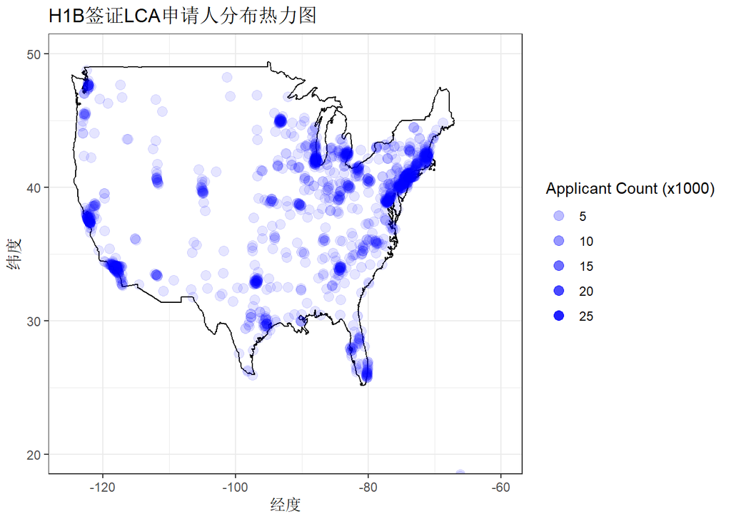

```r
library(ggplot2)
library(dplyr)
# 对 h1b 数据集进行分组
location_counts <- group_by(h1b, WORKSITE, lon, lat) %>%
               summarise( applicant_count = n() / 1000, .groups = "drop")


# 绘制热力图
ggplot() +
  geom_polygon(
    data = map_data("usa"),
    aes(x = long, y = lat, group = group),
    fill = "white",
    color = "black"
  ) +
  geom_point(
    data = location_counts,
    aes(x = lon, y = lat, alpha = applicant_count),
    color = "blue",
    size = 3
  ) +
  scale_alpha_continuous(
    range = c(0.1, 1),
    breaks = seq(0, 30, 5),
    name = "Applicant Count (x1000)"
  ) +
  labs(
    title = "H1B签证LCA申请人分布热力图",
    x = "经度",
    y = "纬度"
  ) +
  theme_bw() +
  coord_cartesian(xlim = c(-125,-60),ylim = c(20,50))
```

根据分布热力图，H1B签证LCA申请人主要分布在东西两侧沿海，且以东侧为主。

### 3.

除了从地理热力图直观的感受数据，请将申请审批时间对应到日历上，来直观感受每一天的审批人数情况。（提示：请根据dcs_year、dcs_yearmonth、dcs_monthweek、dcs_weekday和dcs_dayyear这五个变量分别汇总每天的申请人数（单位：千人），存入到dcs_heat；在R中，根据dcs_heat，利用ggplot函数绘每日申请人数的日历热力图）

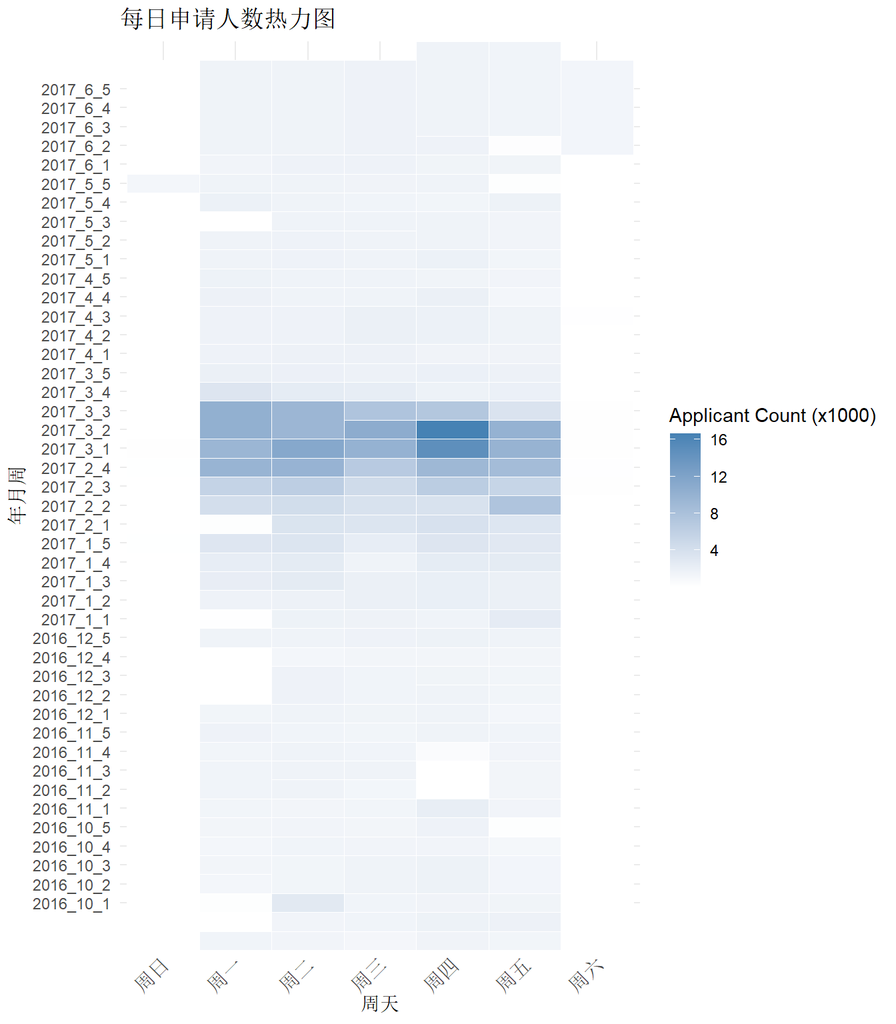

```r
library(dplyr)
library(ggplot2)
library(lubridate)
# 设置图表尺寸
options(repr.plot.height=8)  # 设置图表高度为8英寸

# 汇总每天的申请人数
dcs_heat <- h1b %>%
  mutate(dcs_weekday = wday(DECISION_DATE, label = TRUE),
       sbm_weekday = wday(CASE_SUBMITTED, label = TRUE),
       dcs_yearmonth = parse_date_time(dcs_yearmonth, orders = "my"),
       week_month_year = paste(year(dcs_yearmonth), month(dcs_yearmonth), dcs_monthweek, sep = "_")
)%>%  # 提取审批申请时间中的星期几信息
  group_by(dcs_year,
           dcs_yearmonth,
           dcs_monthweek,
           dcs_weekday,
           dcs_dayyear,
           week_month_year) %>%
  summarise(applicant_count = n() / 1000,         # 汇总每天的申请人数
            .groups = "drop")                     # 取消分组

# 绘制日历热力图
ggplot(dcs_heat, aes(x =dcs_weekday , y =  week_month_year, fill = applicant_count)) +
  geom_tile(color = "white", height = 5) +
  scale_fill_gradient(low = "white", high = "steelblue") +
  labs(x = "周天", y = "年月周", fill = "Applicant Count (x1000)",
       title = "每日申请人数热力图") +
  theme_minimal() +
  theme(axis.text.x = element_text(angle = 45, hjust = 1))
```

根据日历热力图显示，申请审批主要位于工作日，说明审批与否主要看部门是否上班；此外，2017年2-3月是审批最多的，可能是因为这一时段申请人数也最多。

### 4.

绘制画雇佣关系持续时间与申请状态的关系图。（提示：根据duration_class和CASE_STATUS两个变量汇总出各类受雇时长的申请状态，计算处不同受雇时长类别中申请状态的百分比，从而绘制对应的统计图）

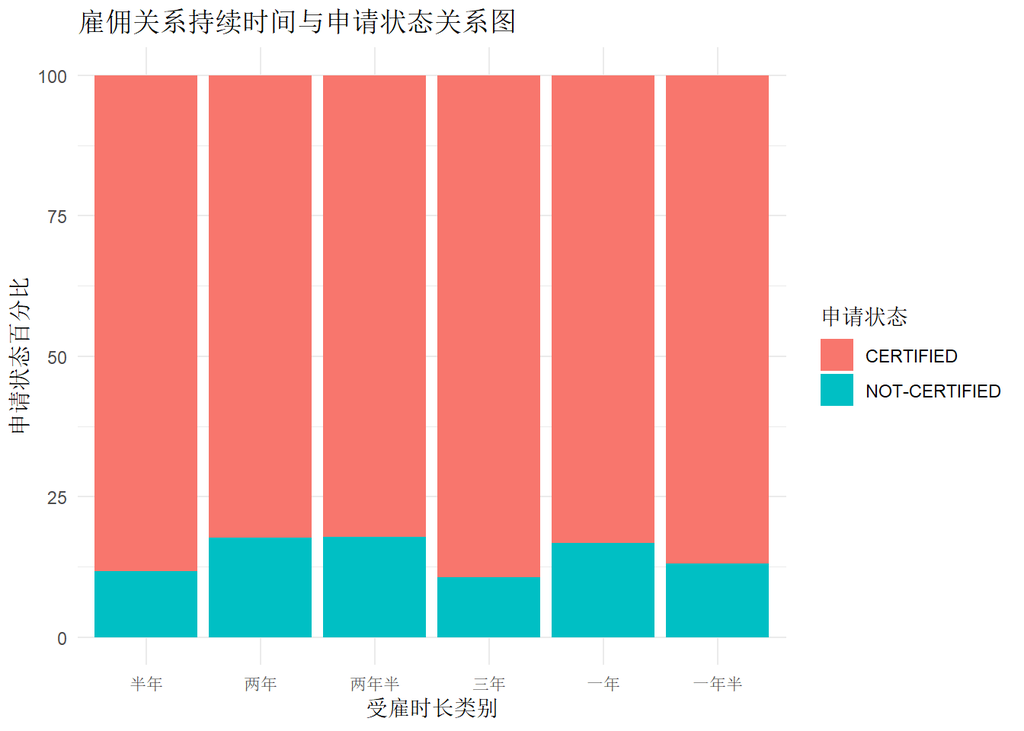

```r
library(dplyr)
library(ggplot2)
options(dplyr.summarise.inform = FALSE)

# 假设你的数据集为 h1b

# 根据 duration_class 和 CASE_STATUS 汇总数据，并计算百分比
summary_data <- h1b %>%
  group_by(duration_class, CASE_STATUS) %>%
  summarise(count = n()) %>%
  mutate(percentage = count / sum(count) * 100)

# 绘制堆积柱状图
ggplot(summary_data, aes(x = duration_class, y = percentage, fill = CASE_STATUS)) +
  geom_bar(stat = "identity", position = "stack") +
  labs(x = "受雇时长类别", y = "申请状态百分比", fill = "申请状态") +
  ggtitle("雇佣关系持续时间与申请状态关系图") +
  theme_minimal()
```

可见，受雇时长为一年、两年和两年半的组别 not-certifie的的比例最高。

### 5.

绘制各类数据岗位在美国的最低工资与申请状态关系图，其中，提取SOC_NAME变量中MANAGEMENT ANALYSTS、OPERATIONS RESEARCH ANALYSTS、FINANCIAL ANALYSTS、MARKET RESEARCH ANALYSTS、STATISTICIANS和COMPUTER PROGRAMMERS这六类职业，将其英文名改为相应的中文名，分别为：管理分析师、运行分析师、金融分析师、市场分析师、统计学家和程序员。（提示：利用ggplot函数绘制出各职业不同申请状态下的最低工资（WAGE_RATE_OF_PAY_FROM）的箱线图）

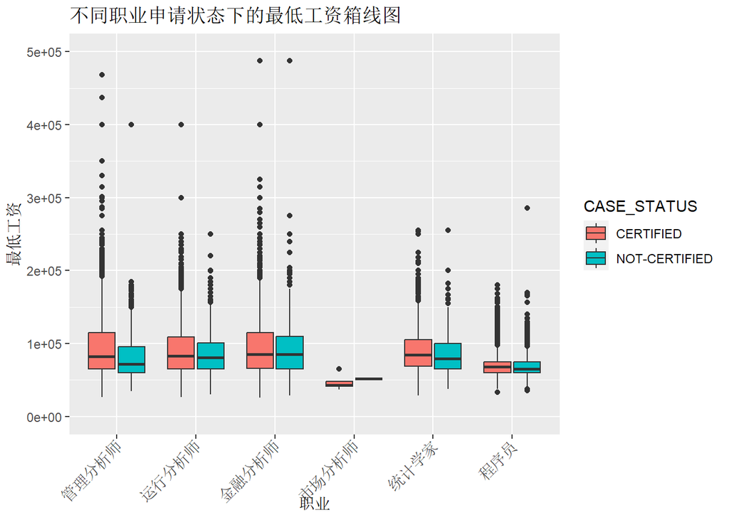

```r
library(dplyr)
library(ggplot2)

# 提取所需职业并修改英文名称为中文名称
selected_occupations <- c("MANAGEMENT ANALYSTS" = "管理分析师",
                          "OPERATIONS RESEARCH ANALYSTS" = "运行分析师",
                          "FINANCIAL ANALYSTS" = "金融分析师",
                          "MARKET RESEARCH ANALYSTS" = "市场分析师",
                          "STATISTICIANS" = "统计学家",
                          "COMPUTER PROGRAMMERS" = "程序员")

# 从数据中筛选出所需职业
filtered_data <- h1b %>%
  filter(SOC_NAME %in% names(selected_occupations)) %>%
  mutate(SOC_NAME = factor(SOC_NAME, levels = names(selected_occupations), labels = selected_occupations))

# 绘制箱线图
ggplot(filtered_data, aes(x = SOC_NAME, y = WAGE_RATE_OF_PAY_FROM, fill = CASE_STATUS)) +
  geom_boxplot() +
  labs(x = "职业", y = "最低工资", title = "不同职业申请状态下的最低工资箱线图") +
  theme(axis.text.x = element_text(angle = 45, hjust = 1)) +
  coord_cartesian(ylim = c(0, 500000))
```

可见除了市场分析师以外，certified状态有助于提升薪资水平，但也很有限。

### 6.

以对申请状态为因变量，以TOTAL_WORKERS、duration_class、certi_duration_class、wage_class、occupation、dcs_weekend、sbm_weekend、dcs_quarter、sbm_quarter和FULL_TIME_POSITION为自变量，建立逻辑回归，探求这些变量对于申请状态的影响，并利用summary函数将回归结果存入到mod.summary。（提示：在R中，利用glm函数建立模型）

```r
# 处理因变量为0-1标签
h1b$CASE_STATUS <- ifelse(h1b$CASE_STATUS == "CERTIFIED", 1, 0)

# 建立逻辑回归模型
mod <- glm(CASE_STATUS ~ TOTAL_WORKERS + duration_class + certi_duration_class + wage_class + occupation + dcs_weekend + sbm_weekend + dcs_quarter + sbm_quarter + FULL_TIME_POSITION,
           data = h1b,
           family = binomial)

# 将回归结果存入mod.summary
mod.summary <- summary(mod)
```

### 7.

根据上述回归模型，计算混淆矩阵，并绘制ROC曲线，标注AUC值。（提示：在R中，使用pROC包中的roc函数绘制曲线）

```r
library(pROC)
# 根据模型预测概率
predicted_probs <- predict(mod, type = "response")

# 计算混淆矩阵
confusion_matrix <- table(Actual = h1b$CASE_STATUS, Predicted = ifelse(predicted_probs > 0.5, "CERTIFIED", "DENIED"))

# 打印混淆矩阵
print(confusion_matrix)
```

```
##       Predicted
## Actual CERTIFIED DENIED
##      0     19018  34988
##      1    436225     13
```

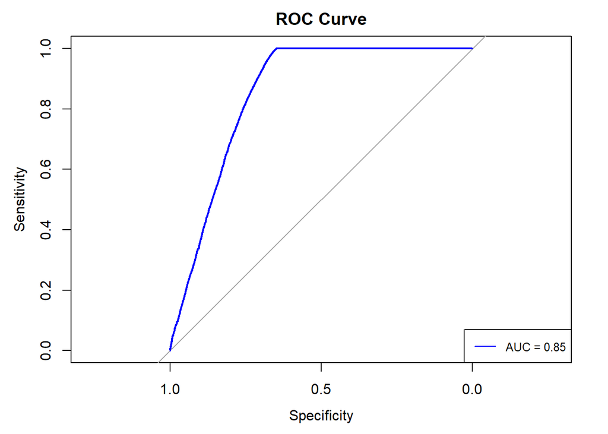

```r
# 计算ROC曲线和AUC值
roc_curve <- roc(h1b$CASE_STATUS, predicted_probs)
auc_value <- auc(roc_curve)

# 绘制ROC曲线
plot(roc_curve, main = "ROC Curve", col = "blue")
legend("bottomright", legend = paste("AUC =", round(auc_value, 2)), col = "blue", lty = 1, cex = 0.8)
```

混淆矩阵说明模型正确预测了绝大多数认证申请，这表明模型在检测正例方面具有较高的准确性；但是负例的错分率较高，将很多未认证的申请预测为认证。

auc =0.85说明模型的分类性能整体不错。